# Exemple de Script facilement convertible en Notebook depuis RStudio

Anne Sabourin

Tue Sep 13 08:46:51 2016

Pour exécuter ce script, ouvrez le avec RStudio et pressez Ctr+Shift+Entrée. Pour l’exécuter et le convertir (compiler) en notebook html, pressez Ctrl+shift+K (il faut avoir installé le package `rmarkdown`).  
Pour obtenir un pdf plutôt qu’un html (déconseillé), remplacez `output: html_document` par `output: pdf_document` dans l’en-tête ci-dessus.

```r
print("exemple de calcul")
```

```
## [1] "exemple de calcul"
```

```r
pommes = 3 ;
poires = 8;
fruits = pommes + poires ;
fruits
```

```
## [1] 11
```

```r
## Ceci est une ligne de  commentaire
```

Ceci est une autre ligne de commentaire. Quelle est la différence ? pour le savoir: compilez le notebook depuis RStudio.

**Figures**: elles apparaissent sous le code les ayant générées, automatiquement. Générons par exemple des données sous une loi normale standard et traçons l’histogramme:

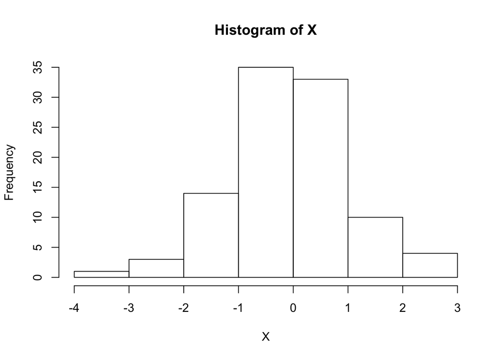

```r
X = rnorm(100)
hist(X)
```

```r
## Ici je ferais des commentaires si je devais interpréter cette figure.
```

Dans un fichier script comme celui-ci, vous pouvez insérer des commentaires (visibles dans le notebook mais pas exécutés) grâce aux symboles # ou #’ . Une fois le fichier exporté au format notebook (Menu -> File -> Compile Notebook ou Ctrl+Shift+K),

- Les lignes commençant par # ou ## apparaissent dans les “code chunks” (les encadrés contenant du code et le résultat).
- Les lignes commençant par #’ apparaissent normalement et le retour à la ligne s’effectue automatiquement. Pour forcer le retour à la ligne: rajouter deux espaces à la fin de la ligne comme ceci:  
  Nous sommes passés à la ligne suivante.

**Equations, symboles mathématiques**: Vous pouvez insérer des équations en langage LaTeX dans les commentaires du script comme ceci: $y = x+3$, ou $y^3 = \cos\theta$ ; ou encore hors ligne comme ceci:
$$\mathbb{E}_\theta(X) = \int_{x\in\mathcal{X}} x \; p_\theta(x) \mu(dx).$$